# PISA 2012 - Student-Teacher Relationship

## by Verena Dietrich

## Dataset Overview

"PISA 2012 is the programme’s 5th survey. It assessed the competencies of 15-year-olds in reading, mathematics and science (with a focus on mathematics) in 65 countries and economies. In 44 of those countries and economies about 85 000 students also took part in an optional assessment of creative problem solving; and in 18 countries and economies, students were assessed in financial literacy.

Around 510 000 students between the ages of 15 years 3 months and 16 years 2 months participated in PISA 2012 as a whole representing about 28 million 15-year-olds globally." [https://www.oecd.org/pisa/keyfindings/pisa-2012-results.htm, June 2021]

## Investigation Overview

That the parents' involvement/engagement has highly positive impact on the children's success in school is known (https://www.oecd.org/pisa/49012097.pdf). I am wondering how the teacher's relationship influences the children's success and if there is a difference between femal eand male students.

In this context a relationship is defined as positive if the student gets along with the teacher, and the student has the feeling that the teacher is interested, listens, helps and treats the students fair. A relationship is defined as negative if this points are not given. The rating is devided into "strongly agree", "agree", disagree" and "strongly disagree" with the statements "Get along with teachers.", "Teachers are interested.", "Teachers listen to students.", "Teachers help students." and "Teachers treat students fair."

[figure not shown]

```python
plt.pie([positive,negative], labels = labels, colors = colors,  autopct='%.1f%%', startangle=90)
plt.title('Students rating the relationship to their teachers');
```

In this context a relationship is defined as positive if the student gets along with the teacher, and the student has the feeling that the teacher is interested, listens, helps and treats the students fair. A relationship is defined as negative if this points are not given.

### There is no big difference between male and female students rating the relationship to the teacher

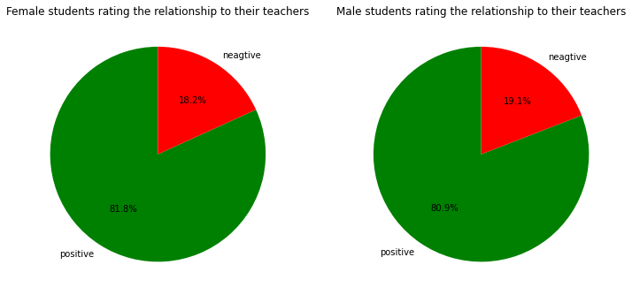

```python
plt.figure(figsize = [12,8])
plt.subplot(1,2,1)
plt.pie([fem_pos,fem_neg], labels = labels, colors = colors,  autopct='%.1f%%', startangle=90)
plt.title('Female students rating the relationship to their teachers');
plt.subplot(1,2,2)
plt.pie([mal_pos,mal_neg], labels = labels, colors = colors,  autopct='%.1f%%', startangle=90)
plt.title('Male students rating the relationship to their teachers');
```

### A good student teacher relationship influences the student's success positively, but not in a strong way

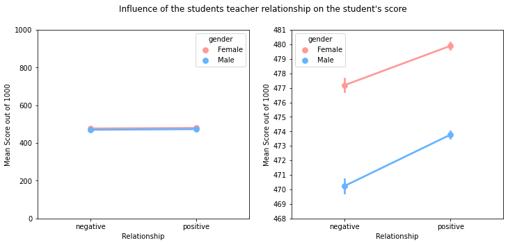

```python
plt.figure(figsize = [12,5])
plt.subplot(1,2,1)
sb.pointplot(data = df_melt_relation, x = 'relation_positive', y = 'score_mean', hue = 'gender', palette=palette);
plt.ylim((0,1000)), plt.ylabel('Mean Score out of 1000'), plt.xlabel('Relationship'), plt.xticks(np.arange(2),
    ['negative','positive'])
plt.subplot(1,2,2)
sb.pointplot(data = df_melt_relation, x = 'relation_positive', y = 'score_mean', hue = 'gender',
    palette=palette)
plt.ylabel('Mean Score out of 1000'), plt.xlabel('Relationship'), plt.xticks(np.arange(2), ['negative','positive']),
plt.yticks(np.arange(468, 482, step=1)), plt.suptitle("Influence of the students teacher relationship on the student's score");
```

### Surprisingly, a very good student teacher relationship correlates with decreased scores

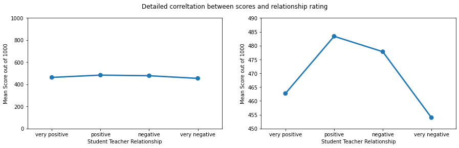

```python
plt.figure(figsize = [15,4])
plt.subplot(1,2,1)
sb.pointplot(data = df_melt_relation, x = 'value', y = 'score_mean',  order = order)
plt.ylim((0,1000)), plt.xlabel('Student Teacher Relationship'), plt.xticks(np.arange(4), categories)
plt.ylabel('Mean Score out of 1000')
plt.subplot(1,2,2)
sb.pointplot(data = df_melt_relation, x = 'value', y = 'score_mean',  order = order, ci = None)
plt.xlabel('Student Teacher Relationship'), plt.xticks(np.arange(4), categories), plt.ylabel('Mean Score out of 1000')
plt.ylim((450,490))
plt.suptitle('Detailed correltation between scores and relationship rating');
```

## This correlation is independet of the gender and the subject.

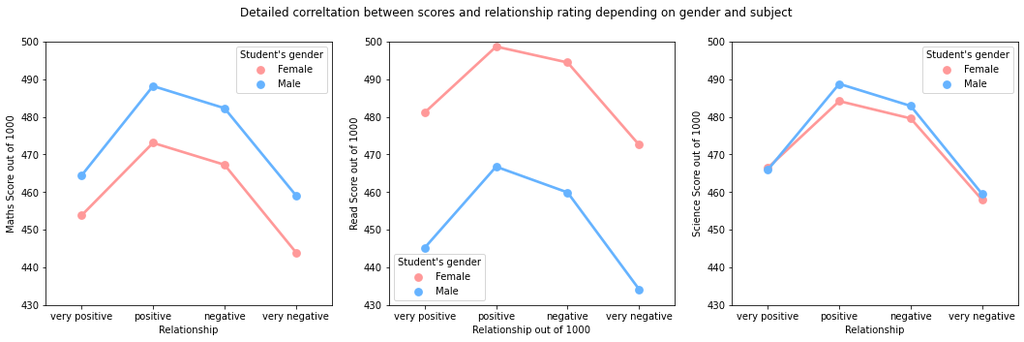

```python
plt.figure(figsize = [18,5])
plt.subplot(1,3,1)
sb.pointplot(data = df_melt_relation, x = 'value', y = 'score_maths', hue = 'gender', order = order, palette=palette, ci = None)
plt.ylabel('Maths Score out of 1000'), plt.xlabel('Relationship') ,plt.xticks(np.arange(4), categories)
plt.legend(title = "Student's gender"), plt.ylim((430,500))
plt.subplot(1,3,2)
sb.pointplot(data = df_melt_relation, x = 'value', y = 'score_read', hue = 'gender', order = order, palette=palette, ci = None)
plt.ylabel('Read Score out of 1000'), plt.xlabel('Relationship out of 1000'), plt.xticks(np.arange(4), categories)
plt.legend(title = "Student's gender"), plt.ylim((430,500))
plt.subplot(1,3,3)
sb.pointplot(data = df_melt_relation, x = 'value', y = 'score_science', hue = 'gender', order = order, palette=palette, ci = None)
plt.ylabel('Science Score out of 1000'), plt.xlabel('Relationship'), plt.xticks(np.arange(4), categories)
plt.legend(title = "Student's gender"), plt.ylim((430,500))
plt.suptitle('Detailed correltation between scores and relationship rating depending on gender and subject');
```

## Summary

We could see, that a positive student teacher relationship correlates with better results.

We could also see, that a very good relationship correlates with decreased scores. We have to be careful and distinguish between causality and correlation. A possible explanation why a very good student teacher relationship seems to decrease the success of the students could be the school types. For the school types with students who have learning deficits could have a in general smaller classes and a stronger focus on a good student teacher relationship and therefore a better students teacher relationship, but lower scores per definition.